# Case Study: How Does a Bike-Share Navigate Speedy Success?

Kacper Fabijański

2023-05-13

## Ask - Introduction with clear statement of business task

Until now, Cyclistic’s marketing strategy relied on building general awareness and appealing to broad consumer segments. One approach that helped make these things possible was the flexibility of its pricing plans: single-ride passes, full-day passes, and annual memberships. Customers who purchase single-ride or full-day passes are referred to as **casual riders**. Customers who purchase annual memberships are **Cyclistic members**

**Cyclistic’s finance analysts have concluded that annual members are much more profitable than casual riders.** Although the pricing flexibility helps Cyclistic attract more customers, Lily Moreno, the director of marketing believes that maximizing the number of annual members will be key to future growth. Rather than creating a marketing campaign that targets all-new customers, **Moreno believes there is a very good chance to convert casual riders into members.** She notes that casual riders are already aware of the Cyclistic program and have chosen Cyclistic for their mobility needs.

**Key stakeholders:**

**Lily Moreno:** The director of marketing - responsible for the development of campaigns and initiatives to promote the bike-share program.

**Marketing analytics team:** responsible for collecting, analyzing, and reporting data that helps guide Cyclistic marketing strategy.

**Executive team:** will decide whether to approve the recommended marketing program

**Business task:** Identify how do annual members and casual riders use Cyclistic bikes differently.

## Prepare - A description of all data sources used

**Load tidyverse**:

```r
library(tidyverse)
library(skimr)
library(janitor)
library(lubridate)
library(chron)
```

```r
library(ggplot2)
```

**Data used:** last 12 months of Cyclistic trip data from 05.2022 to 04.2023 avalaible [here](https://divvy-tripdata.s3.amazonaws.com/index.html).

**Loading data** - first let’s load all 12 csv files

```r
X202205 <- read_csv("CSV/202205-divvy-tripdata.csv")
X202206 <- read_csv("CSV/202206-divvy-tripdata.csv")
X202207 <- read_csv("CSV/202207-divvy-tripdata.csv")
X202208 <- read_csv("CSV/202208-divvy-tripdata.csv")
X202209 <- read_csv("CSV/202209-divvy-tripdata.csv")
X202210 <- read_csv("CSV/202210-divvy-tripdata.csv")
X202211 <- read_csv("CSV/202211-divvy-tripdata.csv")
X202212 <- read_csv("CSV/202212-divvy-tripdata.csv")
X202301 <- read_csv("CSV/202301-divvy-tripdata.csv")
X202302 <- read_csv("CSV/202302-divvy-tripdata.csv")
X202303 <- read_csv("CSV/202303-divvy-tripdata.csv")
X202304 <- read_csv("CSV/202304-divvy-tripdata.csv")
```

Then First let’s merge all tables and delete single month ones

```r
Tripdata <- rbind(X202205, X202206, X202207, X202208, X202209, X202210, X202211, X202212, X202301, X202302, X202303, X202304)
```

```r
remove(X202205)
remove(X202206)
remove(X202207)
remove(X202208)
remove(X202209)
remove(X202210)
remove(X202211)
remove(X202212)
remove(X202301)
remove(X202302)
remove(X202303)
remove(X202304)
```

Let’s see how data is organized by checking column names and first rows using glimpse() and head() functions.

```r
glimpse(Tripdata)
```

```
## Rows: 5,859,061
## Columns: 13
## $ ride_id            <chr> "EC2DE40644C6B0F4", "1C31AD03897EE385", "1542FBEC83…
## $ rideable_type      <chr> "classic_bike", "classic_bike", "classic_bike", "cl…
## $ started_at         <dttm> 2022-05-23 23:06:58, 2022-05-11 08:53:28, 2022-05-…
## $ ended_at           <dttm> 2022-05-23 23:40:19, 2022-05-11 09:31:22, 2022-05-…
## $ start_station_name <chr> "Wabash Ave & Grand Ave", "DuSable Lake Shore Dr & …
## $ start_station_id   <chr> "TA1307000117", "13300", "TA1305000032", "TA1305000…
## $ end_station_name   <chr> "Halsted St & Roscoe St", "Field Blvd & South Water…
## $ end_station_id     <chr> "TA1309000025", "15534", "13221", "TA1305000030", "…
## $ start_lat          <dbl> 41.89147, 41.88096, 41.88224, 41.88224, 41.88224, 4…
## $ start_lng          <dbl> -87.62676, -87.61674, -87.64107, -87.64107, -87.641…
## $ end_lat            <dbl> 41.94367, 41.88635, 41.90765, 41.88458, 41.88578, 4…
## $ end_lng            <dbl> -87.64895, -87.61752, -87.67255, -87.63189, -87.651…
## $ member_casual      <chr> "member", "member", "member", "member", "member", "…
```

```r
head(Tripdata)
```

```
## # A tibble: 6 × 13
##   ride_id          rideable_type started_at          ended_at
##   <chr>            <chr>         <dttm>              <dttm>
## 1 EC2DE40644C6B0F4 classic_bike  2022-05-23 23:06:58 2022-05-23 23:40:19
## 2 1C31AD03897EE385 classic_bike  2022-05-11 08:53:28 2022-05-11 09:31:22
## 3 1542FBEC830415CF classic_bike  2022-05-26 18:36:28 2022-05-26 18:58:18
## 4 6FF59852924528F8 classic_bike  2022-05-10 07:30:07 2022-05-10 07:38:49
## 5 483C52CAAE12E3AC classic_bike  2022-05-10 17:31:56 2022-05-10 17:36:57
## 6 C0A3AA5A614DCE01 classic_bike  2022-05-04 14:48:55 2022-05-04 14:56:04
## # ℹ 9 more variables: start_station_name <chr>, start_station_id <chr>,
## #   end_station_name <chr>, end_station_id <chr>, start_lat <dbl>,
## #   start_lng <dbl>, end_lat <dbl>, end_lng <dbl>, member_casual <chr>
```

At the end I used skim_without_charts() function to see detailed summary of the data

```r
skim_without_charts(Tripdata)
```

Data summary

| Name | Tripdata |
| --- | --- |
| Number of rows | 5859061 |
| Number of columns | 13 |
| _______________________ |  |
| Column type frequency: |  |
| character | 7 |
| numeric | 4 |
| POSIXct | 2 |
| ________________________ |  |
| Group variables | None |

**Variable type: character**

| skim_variable | n_missing | complete_rate | min | max | empty | n_unique | whitespace |
| --- | --- | --- | --- | --- | --- | --- | --- |
| ride_id | 0 | 1.00 | 16 | 16 | 0 | 5859061 | 0 |
| rideable_type | 0 | 1.00 | 11 | 13 | 0 | 3 | 0 |
| start_station_name | 832009 | 0.86 | 3 | 64 | 0 | 1722 | 0 |
| start_station_id | 832141 | 0.86 | 3 | 36 | 0 | 1319 | 0 |
| end_station_name | 889661 | 0.85 | 3 | 64 | 0 | 1741 | 0 |
| end_station_id | 889802 | 0.85 | 3 | 36 | 0 | 1324 | 0 |
| member_casual | 0 | 1.00 | 6 | 6 | 0 | 2 | 0 |

**Variable type: numeric**

| skim_variable | n_missing | complete_rate | mean | sd | p0 | p25 | p50 | p75 | p100 |
| --- | --- | --- | --- | --- | --- | --- | --- | --- | --- |
| start_lat | 0 | 1 | 41.90 | 0.05 | 41.64 | 41.88 | 41.90 | 41.93 | 42.07 |
| start_lng | 0 | 1 | -87.65 | 0.03 | -87.84 | -87.66 | -87.64 | -87.63 | -87.52 |
| end_lat | 5973 | 1 | 41.90 | 0.07 | 0.00 | 41.88 | 41.90 | 41.93 | 42.37 |
| end_lng | 5973 | 1 | -87.65 | 0.11 | -88.14 | -87.66 | -87.64 | -87.63 | 0.00 |

**Variable type: POSIXct**

| skim_variable | n_missing | complete_rate | min | max | median | n_unique |
| --- | --- | --- | --- | --- | --- | --- |
| started_at | 0 | 1 | 2022-05-01 00:00:06 | 2023-04-30 23:59:05 | 2022-08-28 12:44:57 | 4916326 |
| ended_at | 0 | 1 | 2022-05-01 00:05:17 | 2023-05-03 10:37:12 | 2022-08-28 13:07:09 | 4930169 |

**ROCCC**

## Process - Documentation of any cleaning or manipulation of data

**Transforming data**

1. I will day and month columns separately so I can analyze data further.

```r
Tripdata$month <-format(as.Date(Tripdata$started_at), "%m")
Tripdata$day <-format(as.Date(Tripdata$started_at), "%d")
Tripdata$dayoftheweek <-format(as.Date(Tripdata$started_at), "%A")
Tripdata$dayoftheweek <- factor(Tripdata$dayoftheweek, levels = c("Monday", "Tuesday", "Wednesday", "Thursday", "Friday", "Saturday", "Sunday"))
```

2. I will ad column with trip time

```r
Tripdata$trip_time <- difftime(Tripdata$ended_at, Tripdata$started_at)
```

```r
glimpse(Tripdata)
```

```
## Rows: 5,859,061
## Columns: 17
## $ ride_id            <chr> "EC2DE40644C6B0F4", "1C31AD03897EE385", "1542FBEC83…
## $ rideable_type      <chr> "classic_bike", "classic_bike", "classic_bike", "cl…
## $ started_at         <dttm> 2022-05-23 23:06:58, 2022-05-11 08:53:28, 2022-05-…
## $ ended_at           <dttm> 2022-05-23 23:40:19, 2022-05-11 09:31:22, 2022-05-…
## $ start_station_name <chr> "Wabash Ave & Grand Ave", "DuSable Lake Shore Dr & …
## $ start_station_id   <chr> "TA1307000117", "13300", "TA1305000032", "TA1305000…
## $ end_station_name   <chr> "Halsted St & Roscoe St", "Field Blvd & South Water…
## $ end_station_id     <chr> "TA1309000025", "15534", "13221", "TA1305000030", "…
## $ start_lat          <dbl> 41.89147, 41.88096, 41.88224, 41.88224, 41.88224, 4…
## $ start_lng          <dbl> -87.62676, -87.61674, -87.64107, -87.64107, -87.641…
## $ end_lat            <dbl> 41.94367, 41.88635, 41.90765, 41.88458, 41.88578, 4…
## $ end_lng            <dbl> -87.64895, -87.61752, -87.67255, -87.63189, -87.651…
## $ member_casual      <chr> "member", "member", "member", "member", "member", "…
## $ month              <chr> "05", "05", "05", "05", "05", "05", "05", "05", "05…
## $ day                <chr> "23", "11", "26", "10", "10", "04", "27", "29", "16…
## $ dayoftheweek       <fct> Monday, Wednesday, Thursday, Tuesday, Tuesday, Wedn…
## $ trip_time          <drtn> 2001 secs, 2274 secs, 1310 secs, 522 secs, 301 sec…
```

There’s a problem wit trip_time column - minimum value is under 0. With manager we decided to delete this data and analyze only rows with additive trip_time and also delete rows with null values mentioned at ROCC stage.

```r
Tripdatav2 <- Tripdata %>% filter(trip_time > 0) %>% drop_na()
```

Cleaning reduced number of rows from 5 859 061 to 4 533 671

After that - let’s check dataset again using skim_without_charts function

```r
skim_without_charts(Tripdatav2)
```

Data summary

| Name | Tripdatav2 |
| --- | --- |
| Number of rows | 4533671 |
| Number of columns | 17 |
| _______________________ |  |
| Column type frequency: |  |
| character | 9 |
| difftime | 1 |
| factor | 1 |
| numeric | 4 |
| POSIXct | 2 |
| ________________________ |  |
| Group variables | None |

**Variable type: character**

| skim_variable | n_missing | complete_rate | min | max | empty | n_unique | whitespace |
| --- | --- | --- | --- | --- | --- | --- | --- |
| ride_id | 0 | 1 | 16 | 16 | 0 | 4533671 | 0 |
| rideable_type | 0 | 1 | 11 | 13 | 0 | 3 | 0 |
| start_station_name | 0 | 1 | 3 | 64 | 0 | 1613 | 0 |
| start_station_id | 0 | 1 | 3 | 35 | 0 | 1282 | 0 |
| end_station_name | 0 | 1 | 3 | 64 | 0 | 1651 | 0 |
| end_station_id | 0 | 1 | 3 | 36 | 0 | 1292 | 0 |
| member_casual | 0 | 1 | 6 | 6 | 0 | 2 | 0 |
| month | 0 | 1 | 2 | 2 | 0 | 12 | 0 |
| day | 0 | 1 | 2 | 2 | 0 | 31 | 0 |

**Variable type: difftime**

| skim_variable | n_missing | complete_rate | min | max | median | n_unique |
| --- | --- | --- | --- | --- | --- | --- |
| trip_time | 0 | 1 | 1 secs | 1922127 secs | 618 secs | 19600 |

**Variable type: factor**

| skim_variable | n_missing | complete_rate | ordered | n_unique | top_counts |
| --- | --- | --- | --- | --- | --- |
| dayoftheweek | 0 | 1 | FALSE | 7 | Sat: 709663, Thu: 678032, Wed: 652986, Fri: 646662 |

**Variable type: numeric**

| skim_variable | n_missing | complete_rate | mean | sd | p0 | p25 | p50 | p75 | p100 |
| --- | --- | --- | --- | --- | --- | --- | --- | --- | --- |
| start_lat | 0 | 1 | 41.90 | 0.04 | 41.65 | 41.88 | 41.90 | 41.93 | 42.06 |
| start_lng | 0 | 1 | -87.64 | 0.03 | -87.83 | -87.66 | -87.64 | -87.63 | -87.53 |
| end_lat | 0 | 1 | 41.90 | 0.07 | 0.00 | 41.88 | 41.90 | 41.93 | 42.06 |
| end_lng | 0 | 1 | -87.65 | 0.12 | -87.83 | -87.66 | -87.64 | -87.63 | 0.00 |

**Variable type: POSIXct**

| skim_variable | n_missing | complete_rate | min | max | median | n_unique |
| --- | --- | --- | --- | --- | --- | --- |
| started_at | 0 | 1 | 2022-05-01 00:00:06 | 2023-04-30 23:58:48 | 2022-08-26 17:22:46 | 3931889 |
| ended_at | 0 | 1 | 2022-05-01 00:05:17 | 2023-05-01 08:06:56 | 2022-08-26 17:40:33 | 3945781 |

## Analysis

During analysis I will use GGPLOT2 to see if there are any interesting data and correlations to show - keep in mind charts during this stage are draft charts and will be improved at next - share stage.

1.Number of trips per user type with rideable type categories - **there are more members than casual riders, only casual riders use docked bikes**

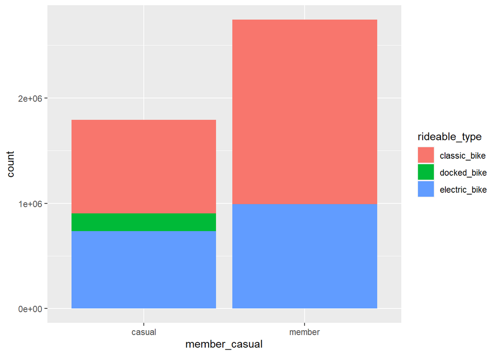

```r
Tripdatav2 %>%
  ggplot(aes(x = member_casual)) + geom_bar(aes(fill = rideable_type))
```

2.Pie charts of rideable type usage per user type - **members use classic bikes instead of docked bikes, also casual riders use electric bikes little more often**

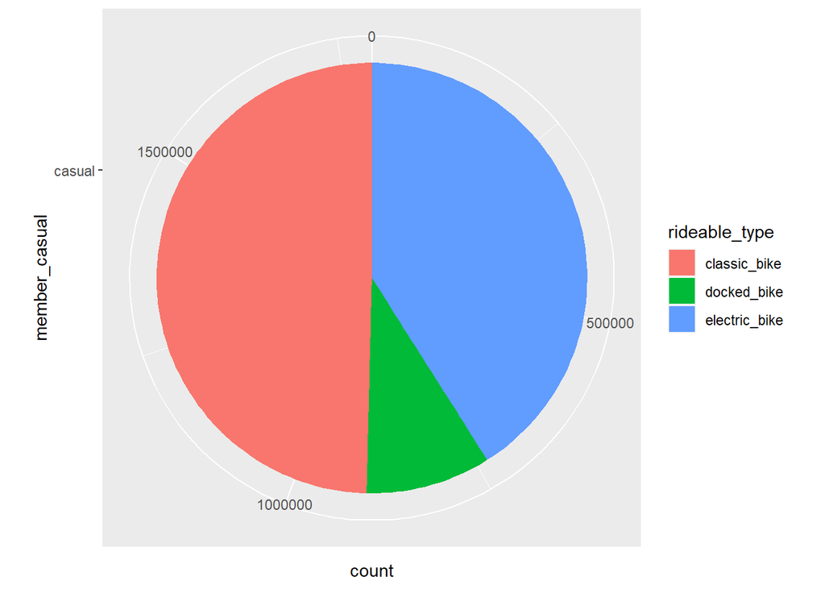

```r
Tripdatav2 %>%
  filter (member_casual == "casual") %>%
  ggplot(aes(x = member_casual, fill=rideable_type)) + geom_bar() + coord_polar(theta = "y")
```

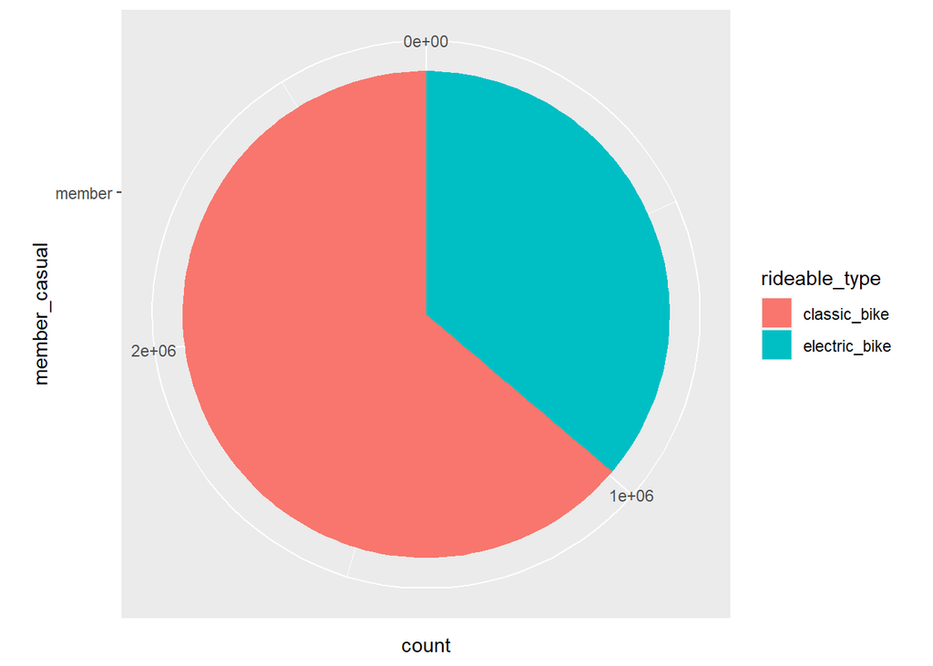

```r
Tripdatav2 %>%
  filter (member_casual == "member") %>%
  ggplot(aes(x = member_casual, fill=rideable_type)) + geom_bar() + coord_polar(theta = "y")
```

3.Avg trip time per user type (trip_time is in seconds so I divided it by 60 to see minutes) - **casual riders spend more time riding a bike**

```
## Defaulting to continuous.
```

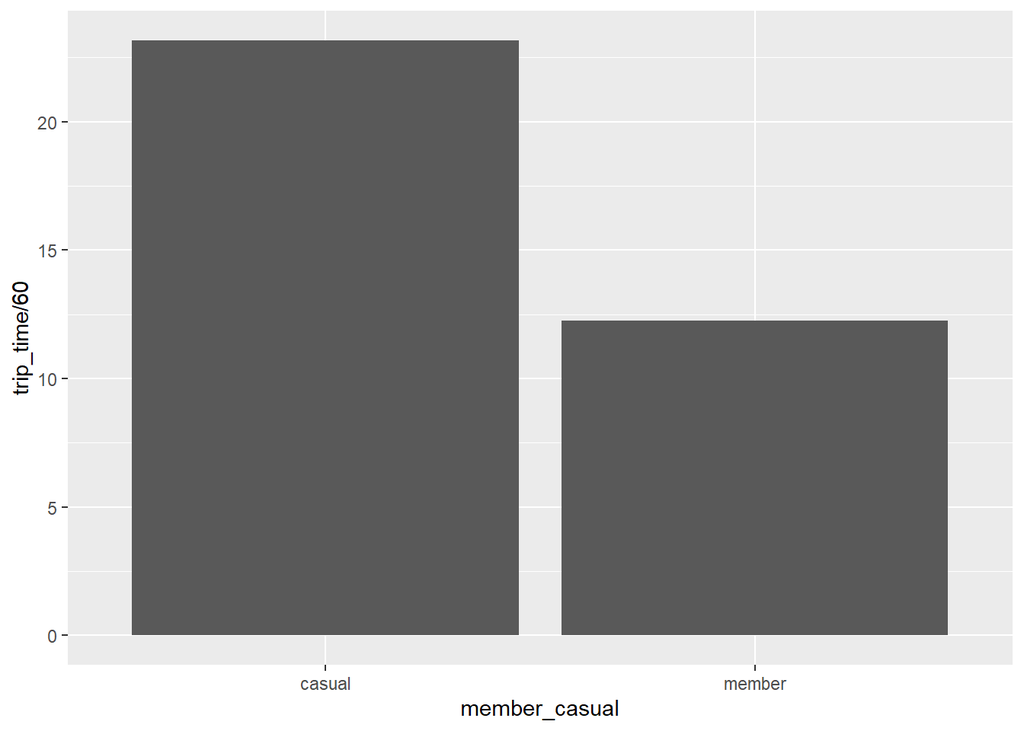

```r
Tripdatav2 %>%
ggplot(aes(x = member_casual, y= trip_time/60)) + geom_bar(stat = "summary", fun = "mean")
```

4.Avg trip time per user type per rideable type - **docked bikes are most time consuming for casual riders, as previously - casual riders spend more times riding a bike**

```
## Defaulting to continuous.
```

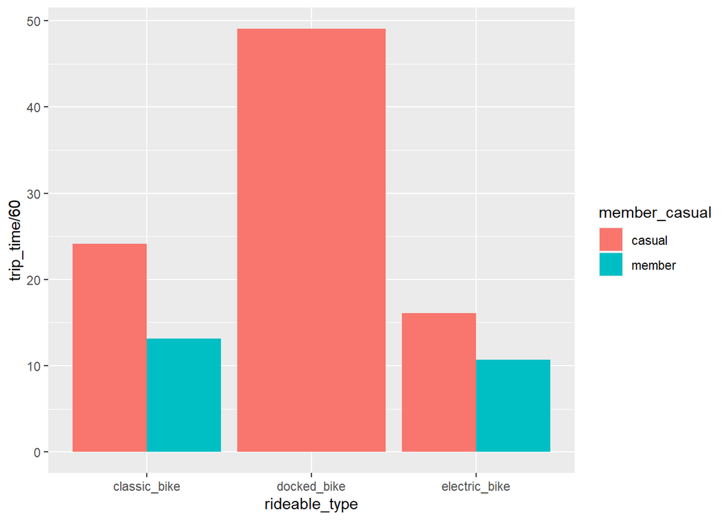

```r
Tripdatav2 %>%
ggplot(aes(x = rideable_type, y= trip_time/60, fill = member_casual)) + geom_bar(stat = "summary", fun = "mean", position = "dodge")
```

5.Histogram of average trip time per user type (values limited to 1h and 2h because otherwise histogram couldn’t be visible) - **most of rides are less than 20minutes but for casual riders we can see more longer rides**

```
## Defaulting to continuous.
```

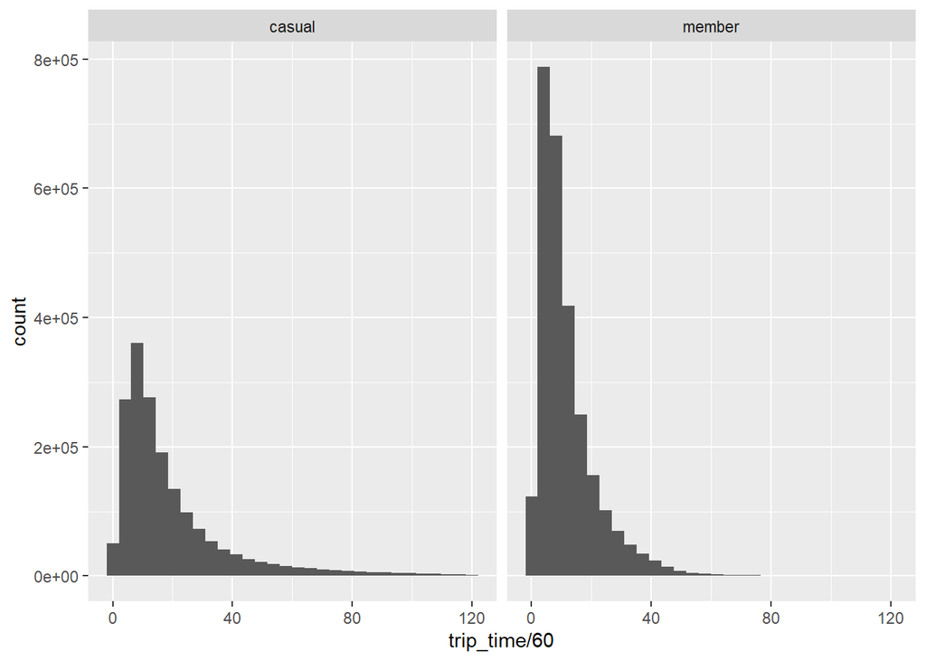

```r
Tripdatav2 %>%
  filter(trip_time < 7200) %>%
  ggplot(aes(x = trip_time/60)) + geom_histogram() + facet_wrap(~member_casual)
```

```
## Defaulting to continuous.
```

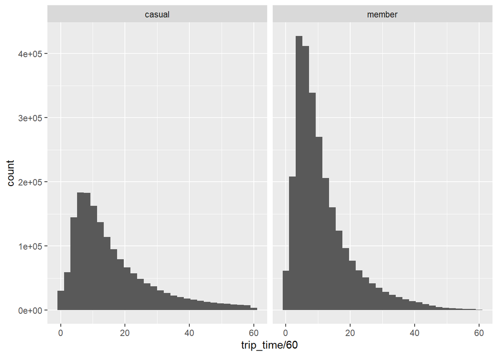

```r
Tripdatav2 %>%
  filter(trip_time < 3600) %>%
  ggplot(aes(x = trip_time/60)) + geom_histogram() + facet_wrap(~member_casual)
```

6.Histogram of average trip time per user type with rideable type categories (values limited to 1h and 2h because otherwise histogram couldn’t be visible) - **docked bikes are more time consuming than average - most of trips are less than 40 minutes, Classic and electric bikes histogram is very similar to overall histogram, we can also confirm that casual riders use electric bikes more often**

```
## Defaulting to continuous.
```

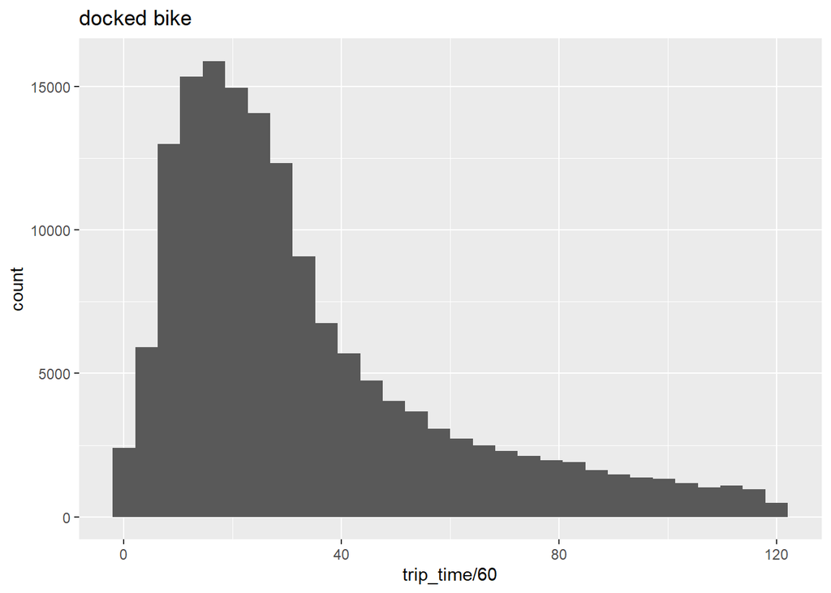

```r
Tripdatav2 %>%
  filter(rideable_type == "docked_bike", trip_time < 7200) %>%
  ggplot(aes(x = trip_time/60)) + geom_histogram() + labs(title = "docked bike")
```

```
## Defaulting to continuous.
```

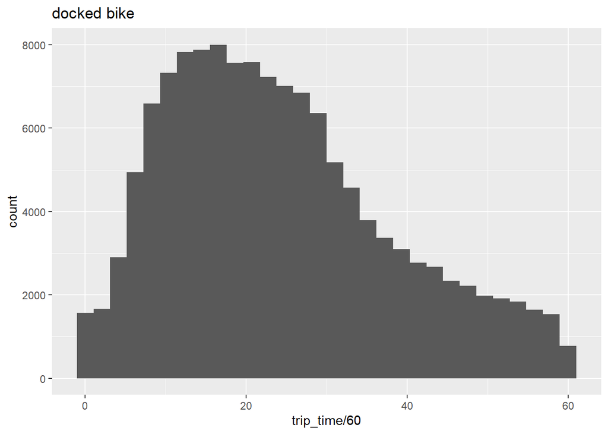

```r
Tripdatav2 %>%
  filter(rideable_type == "docked_bike", trip_time < 3600) %>%
  ggplot(aes(x = trip_time/60)) + geom_histogram() + labs(title = "docked bike")
```

```
## Defaulting to continuous.
```

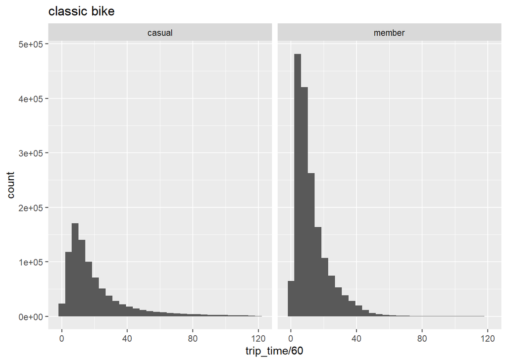

```r
Tripdatav2 %>%
  filter(rideable_type == "classic_bike", trip_time < 7200) %>%
  ggplot(aes(x = trip_time/60)) + geom_histogram() + facet_wrap(~member_casual) + labs(title = "classic bike")
```

```
## Defaulting to continuous.
```

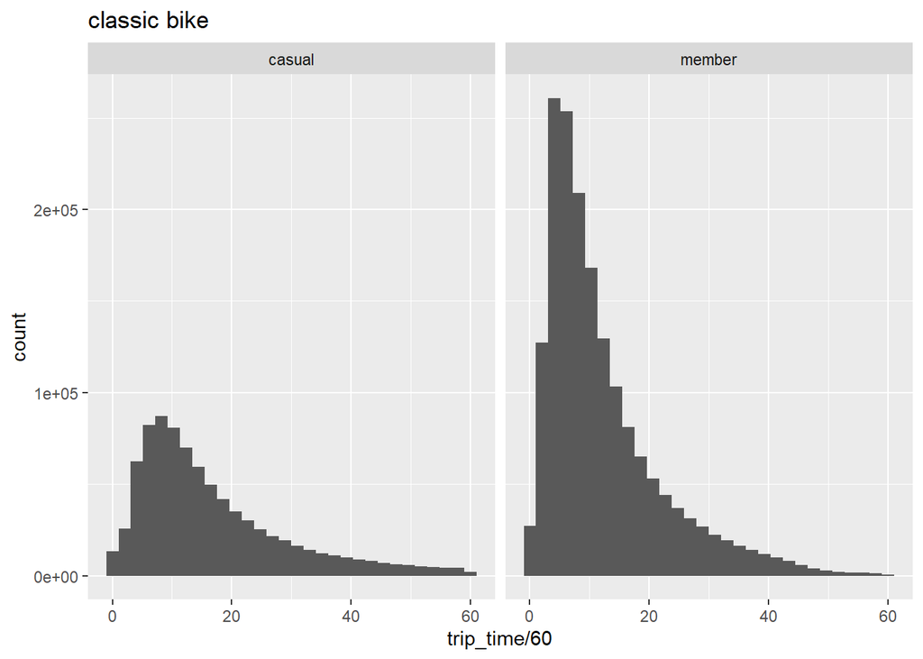

```r
Tripdatav2 %>%
  filter(rideable_type == "classic_bike", trip_time < 3600) %>%
  ggplot(aes(x = trip_time/60)) + geom_histogram() + facet_wrap(~member_casual) + facet_wrap(~member_casual) + labs(title = "classic bike")
```

```
## Defaulting to continuous.
```

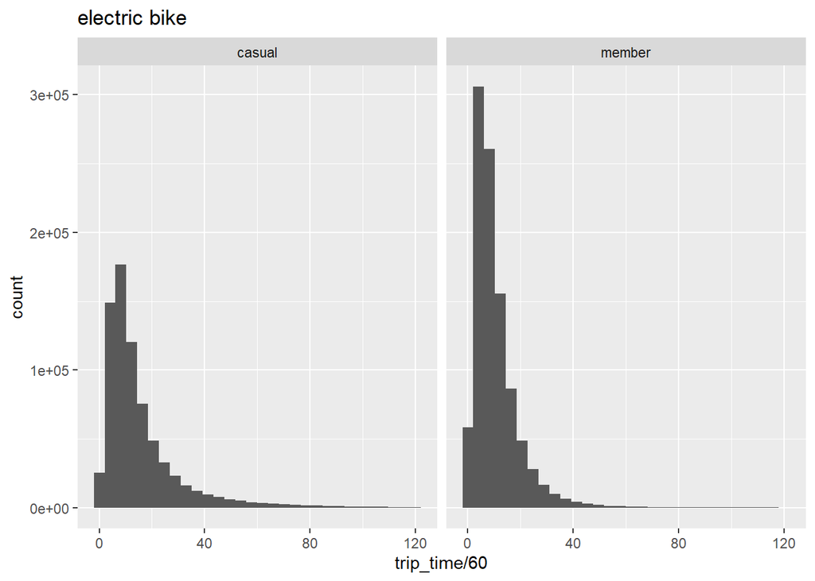

```r
Tripdatav2 %>%
  filter(rideable_type == "electric_bike", trip_time < 7200) %>%
  ggplot(aes(x = trip_time/60)) + geom_histogram() + facet_wrap(~member_casual) + labs(title = "electric bike")
```

```
## Defaulting to continuous.
```

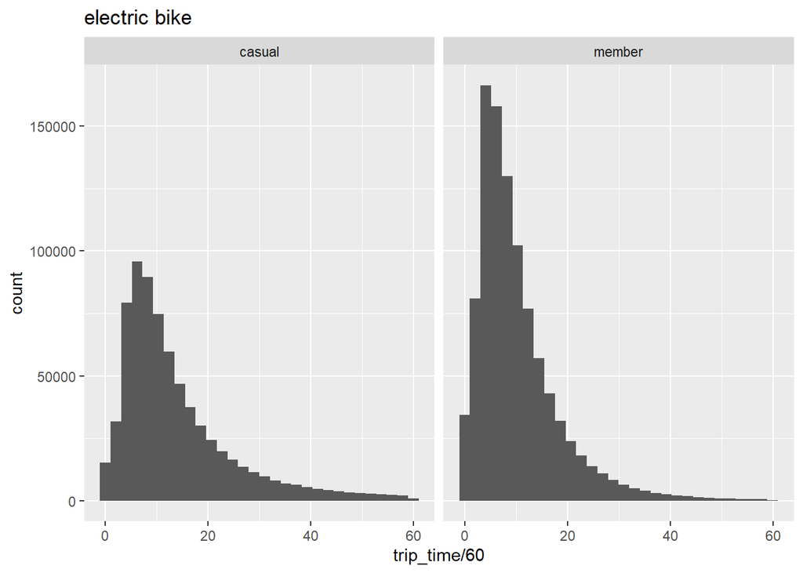

```r
Tripdatav2 %>%
  filter(rideable_type == "electric_bike", trip_time < 3600) %>%
  ggplot(aes(x = trip_time/60)) + geom_histogram() + facet_wrap(~member_casual) + labs(title = "electric bike")
```

7.Avg trip time to month per user type - **beside trip time there are no differences between two groups when it comes to trip time differences in different months - we can observe that during warm days bike trips are usually longer**

```
## Defaulting to continuous.
```

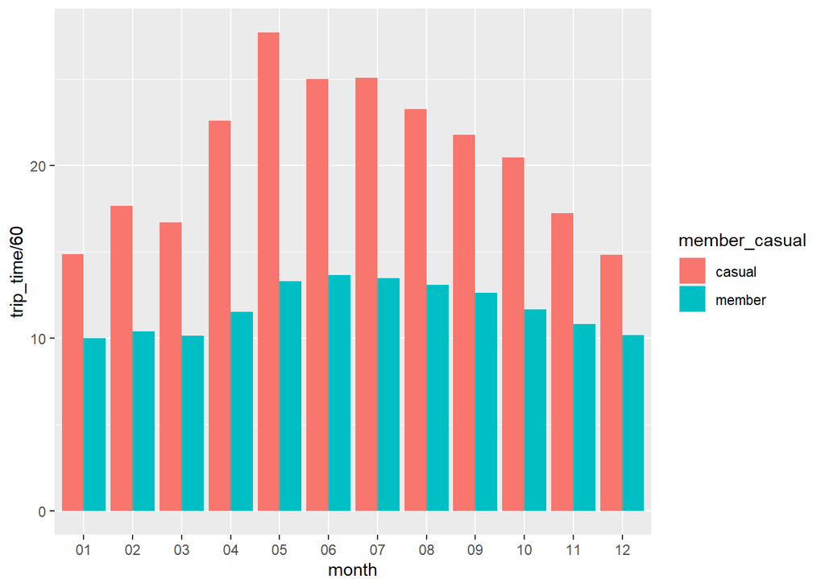

```r
Tripdatav2 %>%
ggplot(aes(x = month, y= trip_time/60, fill=member_casual)) + geom_bar(stat = "summary", fun = "mean", position = "dodge")
```

8.Avg trip time to month per user type per rideable type - **no additional feedback to add for this visualization**

```
## Defaulting to continuous.
```

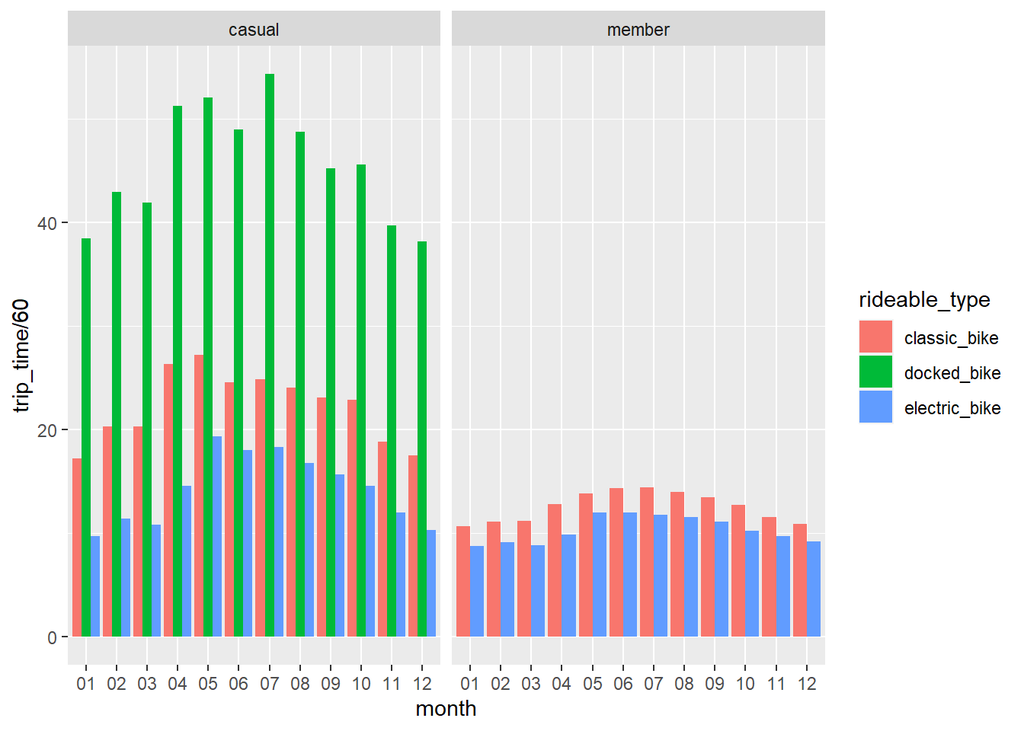

```r
Tripdatav2 %>%
ggplot(aes(x = month, y= trip_time/60, fill=rideable_type)) + geom_bar(stat = "summary", fun = "mean", position = "dodge") + facet_wrap(~member_casual)
```

9.All rides to month per user type - **casual riders are using bikes mainly during warm days where members use it even on colder days (also not as usual as on warm days)**

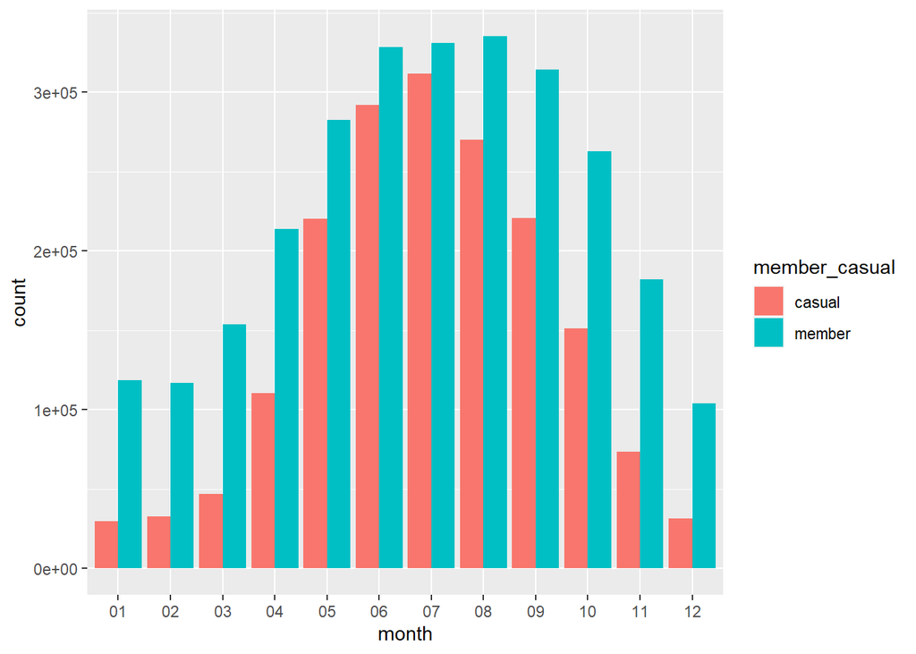

```r
Tripdatav2 %>%
ggplot(aes(x = month, fill = member_casual)) + geom_bar(position = "dodge")
```

10.All rides to month per user type per rideable type - **casual riders tend to use electric bikes more often on cold days where members always use more classic bikes**

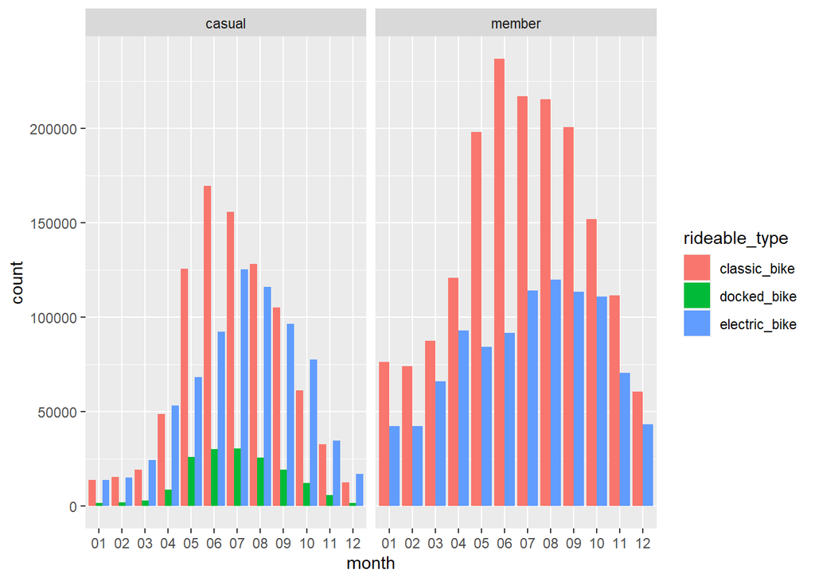

```r
Tripdatav2 %>%
ggplot(aes(x = month, fill = rideable_type)) + geom_bar(position = "dodge") + facet_wrap(~member_casual)
```

11.Summed up trip time to month per user type - **during warm days casual riders spend more time riding a bike than members**

```
## Defaulting to continuous.
```

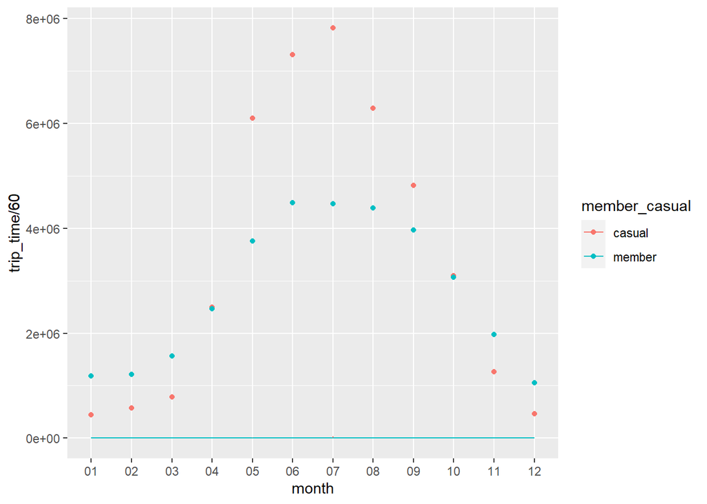

```r
Tripdatav2 %>%
ggplot(aes(x = month, y= trip_time/60, color = member_casual)) + geom_point(stat = "summary", fun = "sum") + geom_line(group = 1)
```

12.Summed up trip time to month per user type - **no additional feedback to add on this chart**

```
## Defaulting to continuous.
```

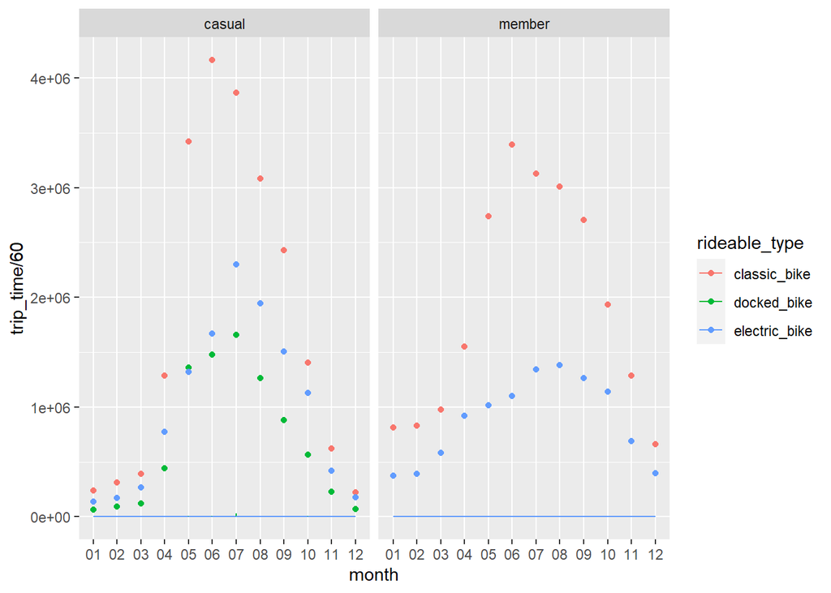

```r
Tripdatav2 %>%
ggplot(aes(x = month, y= trip_time/60, color = rideable_type)) + geom_point(stat = "summary", fun = "sum") + geom_line(group = 1) + facet_wrap(~member_casual)
```

13.Day of the week to average trip time per user type - **for casual riders there’s a trend of increasing trip time from Wednesday to Sunday and decreasing trip time from Sunday to Wednesday, members have longest trips on Saturday**

```
## Defaulting to continuous.
```

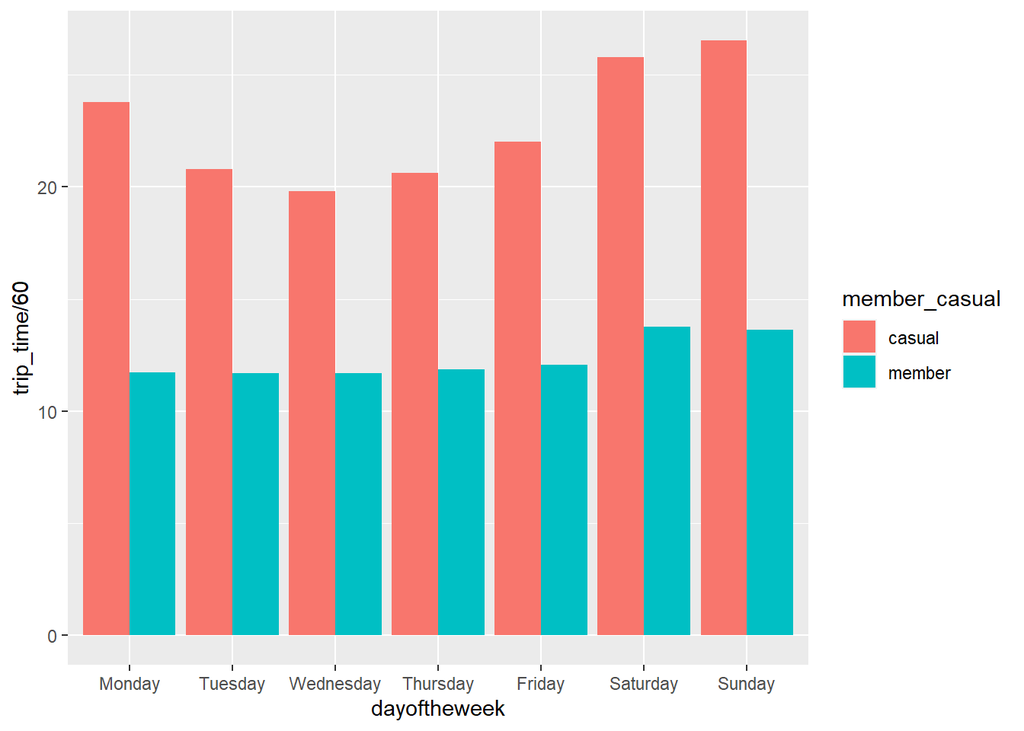

```r
Tripdatav2 %>%
ggplot(aes(x = dayoftheweek, y= trip_time/60, fill=member_casual)) + geom_bar(stat = "summary", fun = "mean", position = "dodge")
```

14.Day of the week to average trip time per user type per rideable type - **here we can see the same trend as on previous visualization**

```
## Defaulting to continuous.
```

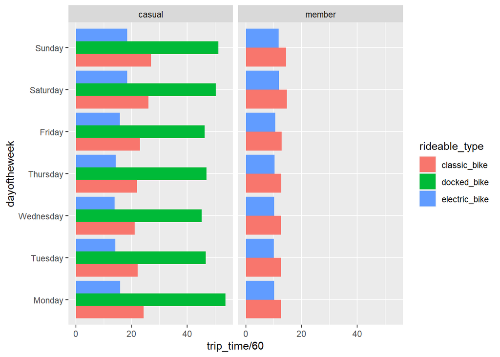

```r
Tripdatav2 %>%
ggplot(aes(x = dayoftheweek, y= trip_time/60, fill=rideable_type)) + geom_bar(stat = "summary", fun = "mean", position = "dodge") + facet_wrap(~member_casual) + coord_flip()
```

15.Day of the week to number of rides per user type - **members perform more rides in working days and casual riders start to ride more on weekend**

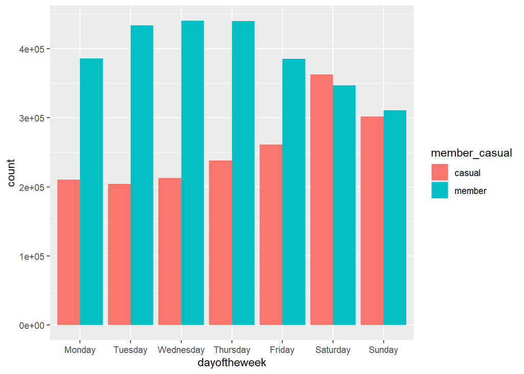

```r
Tripdatav2 %>%
ggplot(aes(x = dayoftheweek, fill = member_casual)) + geom_bar(position = "dodge")
```

16.Day of the week to number of rides per user type per rideable type - **no other trends seen here**

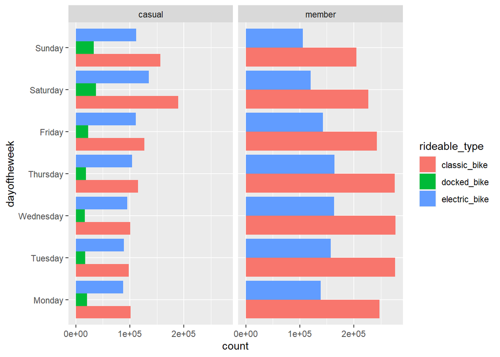

```r
Tripdatav2 %>%
ggplot(aes(x = dayoftheweek, fill = rideable_type)) + geom_bar(position = "dodge") + facet_wrap(~member_casual) + coord_flip()
```

17.Day of the month to average trip time per user type - **we can’t see any new trends from this visualization**

```
## Defaulting to continuous.
```

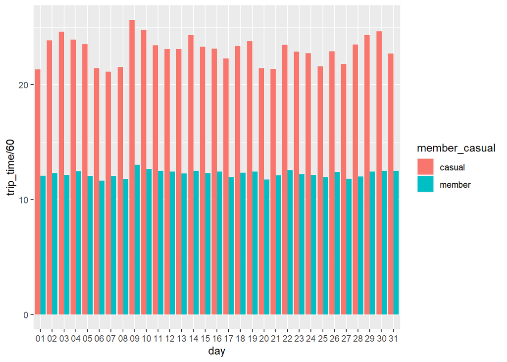

```r
Tripdatav2 %>%
ggplot(aes(x = day, y= trip_time/60, fill=member_casual)) + geom_bar(stat = "summary", fun = "mean", position = "dodge")
```

18.Day of the month to average trip time per user type per rideable type - **we can’t see any new trends from this visualization**

```
## Defaulting to continuous.
```

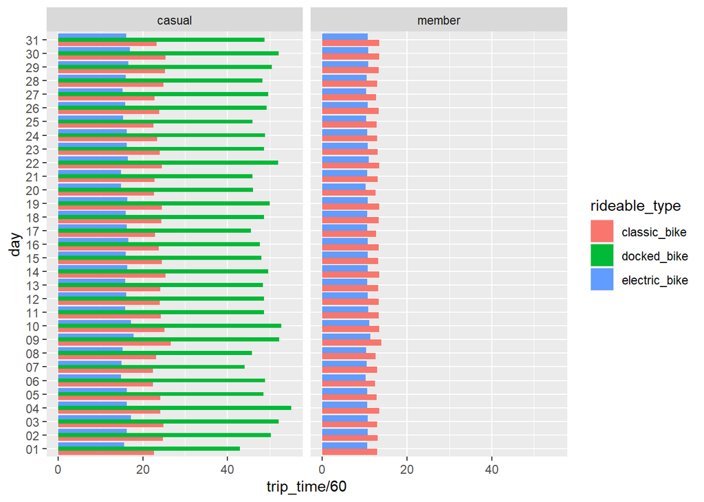

```r
Tripdatav2 %>%
ggplot(aes(x = day, y= trip_time/60, fill=rideable_type)) + geom_bar(stat = "summary", fun = "mean", position = "dodge") + facet_wrap(~member_casual) + coord_flip()
```

19.Day of the month to number of rides per user type - **we can’t see any new trends from this visualization**

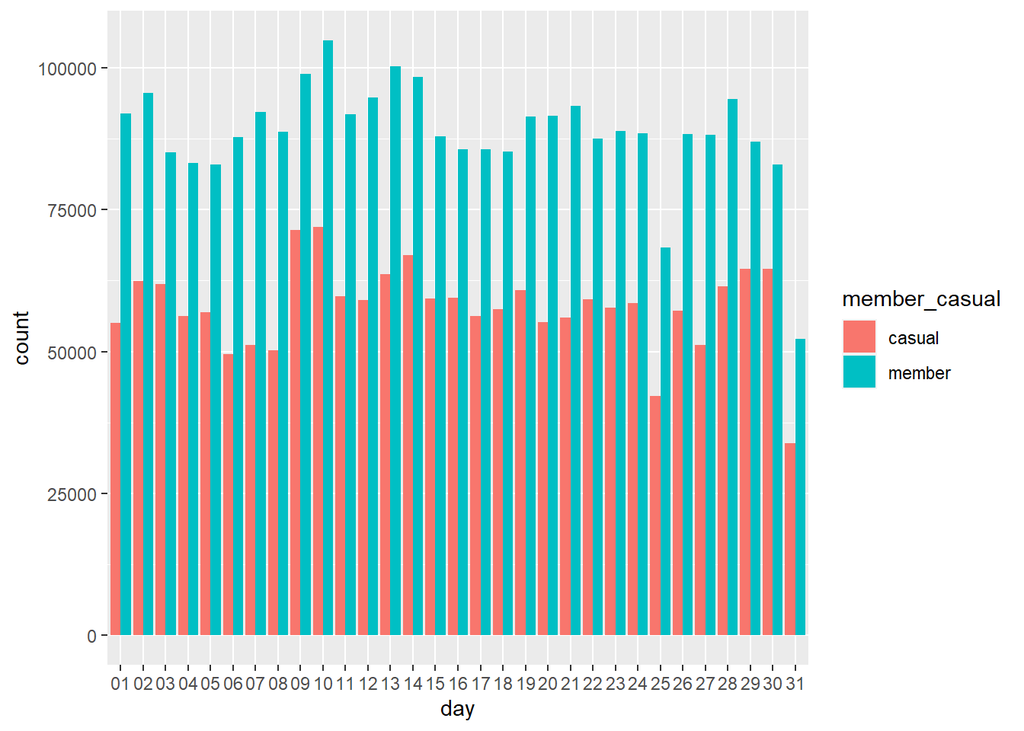

```r
Tripdatav2 %>%
ggplot(aes(x = day, fill = member_casual)) + geom_bar(position = "dodge")
```

20.Day of the month to number of rides per user type per rideable type - **we can’t see any new trends from this visualization**

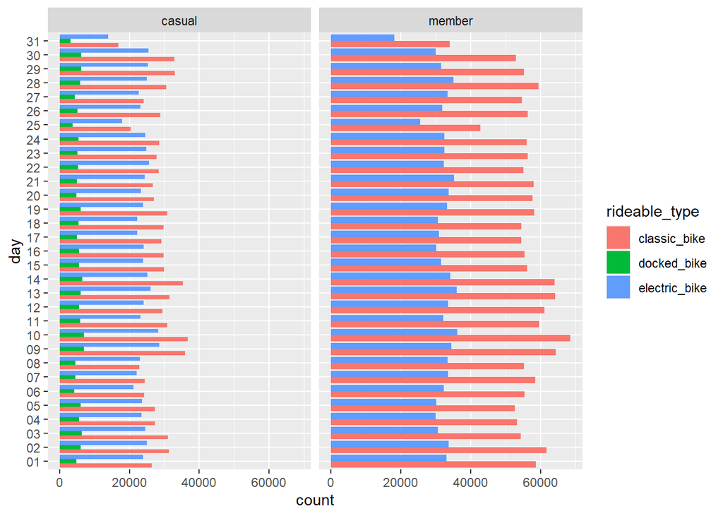

```r
Tripdatav2 %>%
ggplot(aes(x = day, fill = rideable_type)) + geom_bar(position = "dodge") + facet_wrap(~member_casual) + coord_flip()
```

#### Summary:

Visualizations which are good to share for stakeholders are: 1,2,3,4,5,7,9,10,13,15

## Share - Supporting visualizations and key findings

Below there’s a HTML way to describe whole analysis but you can check also presentation [here](https://docs.google.com/presentation/d/e/2PACX-1vRLXcMOGZ6EKo4G_SRFT-CImwp4bbfnQAH7YaIeMrXnAdrEvkpvut5gOYNbmQ4MoODjJwjcVjLuIblr/pub?start=false&loop=false&delayms=3000)

### Business task

Identify how do annual members and casual riders use Cyclistic bikes differently.

Members pay monthy subscriptions so they:

-don’t have to pay 1$ start fee

-don’t have to pay for classic bikes

-pay 0.17$ per min. for using electric bike instead of 0.42$ per min.

### Dataset used

Data used for analysis is first-party data direcly from company’s tracking tool, it shows:

-type of bike used

-start and end date of the trip with separated days of the week and days of the month

-Trip time (created from start and end time of trip)

-User type: member and casual rider

-Cleaning the dataset from rows with NA values reduced number of rows from 5 859 061 to 4 533 671

### Key finding from data

Members performed almost one million rides more over analyzed months

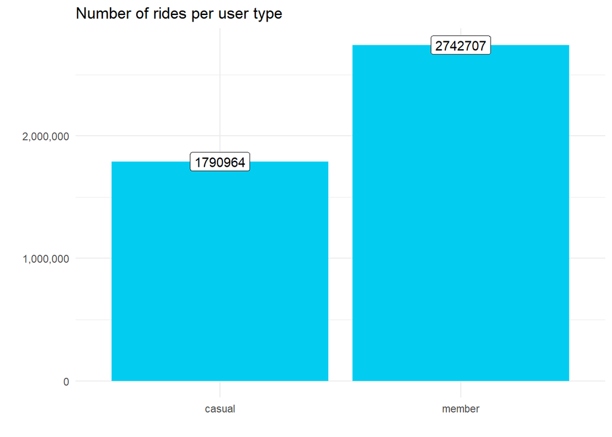

```r
Tripdatav2 %>%
  ggplot(aes(x = member_casual)) + geom_bar(stat = "count", fill = "#02CDF1") + geom_label(stat = 'count', aes(label = ..count..)) + scale_y_continuous(labels = scales::comma) + labs(title = "Number of rides per user type", x ="", y= "") + theme_minimal()
```

Members use classic bikes instead of docked ones. Casual members have little more in electric bikes share

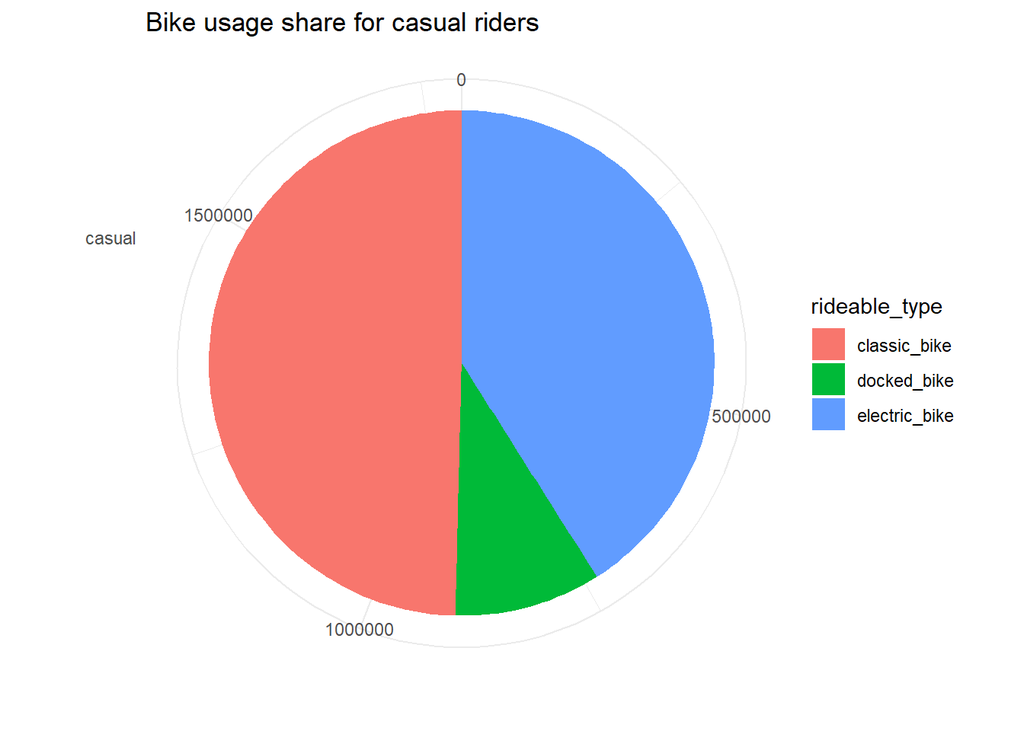

```r
Tripdatav2 %>%
  filter (member_casual == "casual") %>%
  ggplot(aes(x = member_casual, fill=rideable_type)) + geom_bar()+ coord_polar(theta = "y") + labs(title = "Bike usage share for casual riders", x="", y="") + theme_minimal()
```

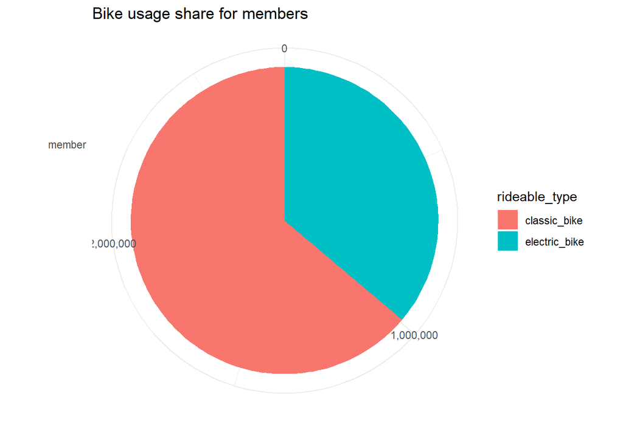

```r
Tripdatav2 %>%
  filter (member_casual == "member") %>%
  ggplot(aes(x = member_casual, fill=rideable_type)) + geom_bar() + coord_polar(theta = "y") + scale_y_continuous(labels = scales::comma) + labs(title = "Bike usage share for members", x="" , y="") + theme_minimal()
```

Casual riders spend more time riding a bike

```
## Defaulting to continuous.
```

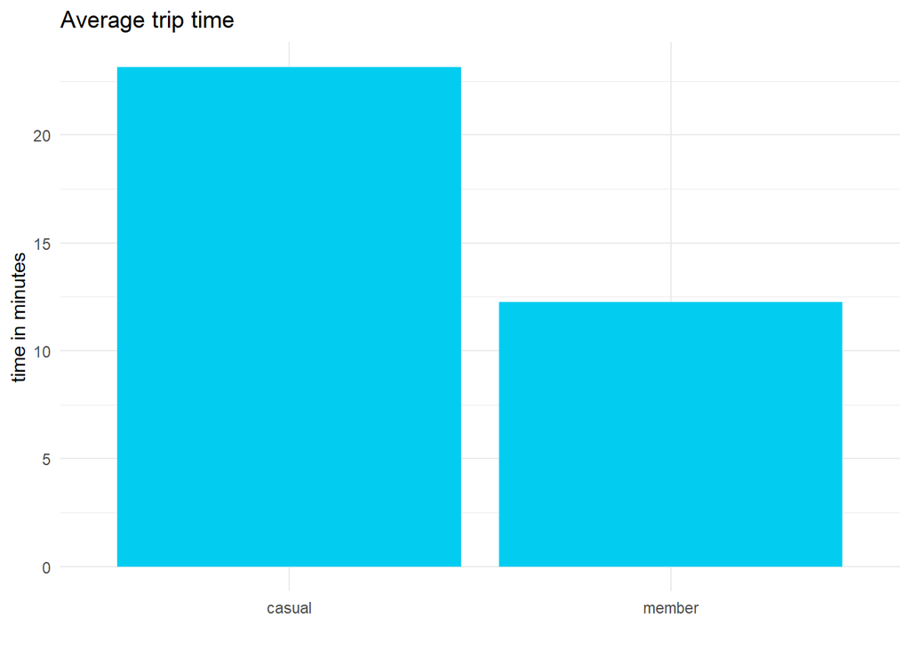

```r
Tripdatav2 %>%
ggplot(aes(x = member_casual, y= trip_time/60)) + geom_bar(stat = "summary", fun = "mean", fill = "#02CDF1") + labs(title = "Average trip time", y = "time in minutes", x = "") + theme_minimal()
```

Casual riders spend more time on every type of bike but docked bikes are the most time consuming for them

```
## Defaulting to continuous.
```

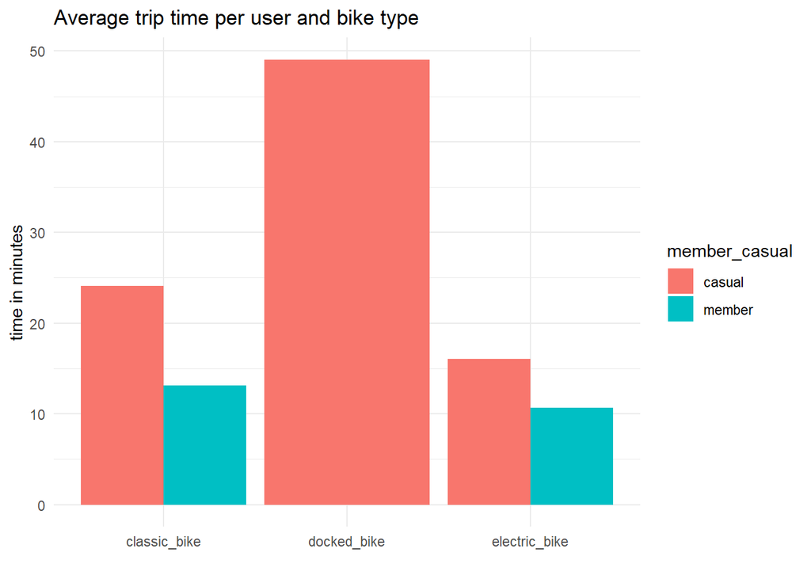

```r
Tripdatav2 %>%
ggplot(aes(x = rideable_type, y= trip_time/60, fill = member_casual)) + geom_bar(stat = "summary", fun = "mean", position = "dodge") + labs(title = "Average trip time per user and bike type", y = "time in minutes", x = "") + theme_minimal()
```

There are two histograms showing trip times up to 1h and up to 2h. Charts look very similar but there are more extremely long values for casual riders.

```
## Defaulting to continuous.
```

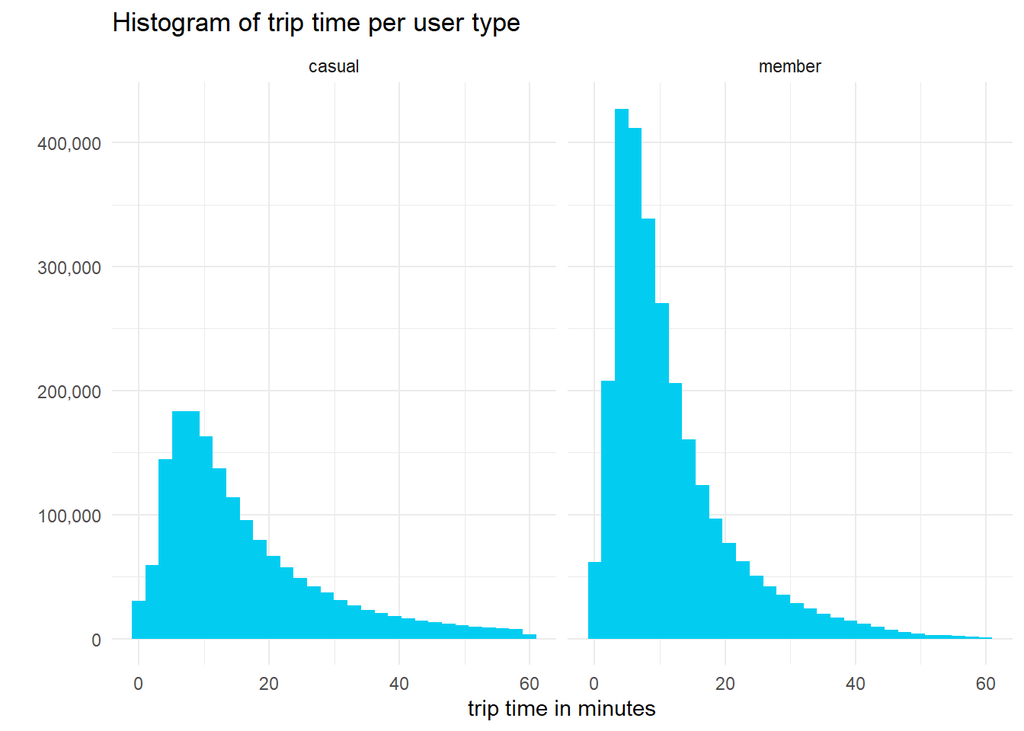

```r
Tripdatav2 %>%
  filter(trip_time < 3600) %>%
  ggplot(aes(x = trip_time/60)) + geom_histogram(fill = "#02CDF1") + facet_wrap(~member_casual) + scale_y_continuous(labels = scales::comma) + labs (title = "Histogram of trip time per user type", x = "trip time in minutes", y ="") + theme_minimal()
```

```
## Defaulting to continuous.
```

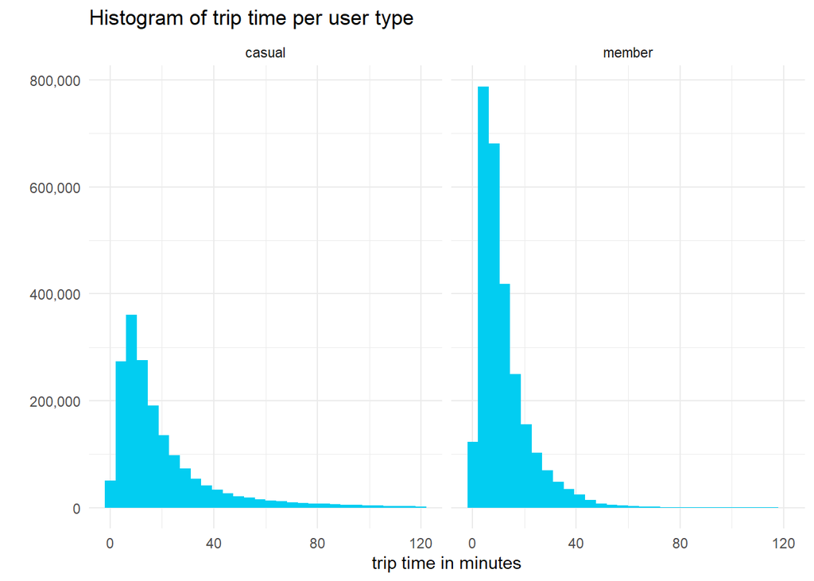

```r
Tripdatav2 %>%
  filter(trip_time < 7200) %>%
  ggplot(aes(x = trip_time/60)) + geom_histogram(fill = "#02CDF1") + facet_wrap(~member_casual) + scale_y_continuous(labels = scales::comma) + labs (title = "Histogram of trip time per user type", x = "trip time in minutes", y ="") + theme_minimal()
```

Chart shows average trip time on different months. During warmer days trips time is usually longer especially for casual riders

```
## Defaulting to continuous.
```

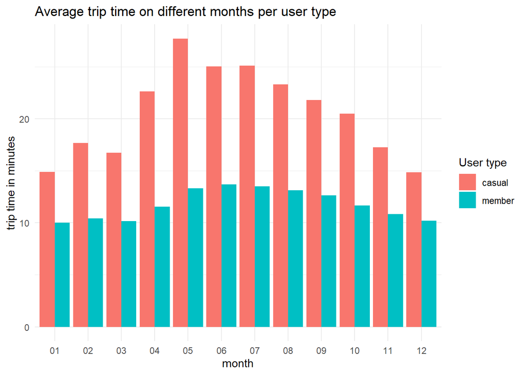

```r
Tripdatav2 %>%
ggplot(aes(x = month, y= trip_time/60, fill=member_casual)) + geom_bar(stat = "summary", fun = "mean", position = "dodge") + labs(title = "Average trip time on different months per user type", x="month", y = "trip time in minutes", fill = "User type") + theme_minimal()
```

Casual riders use bikes mainly during warm seasons where members use it even on colder seasons.

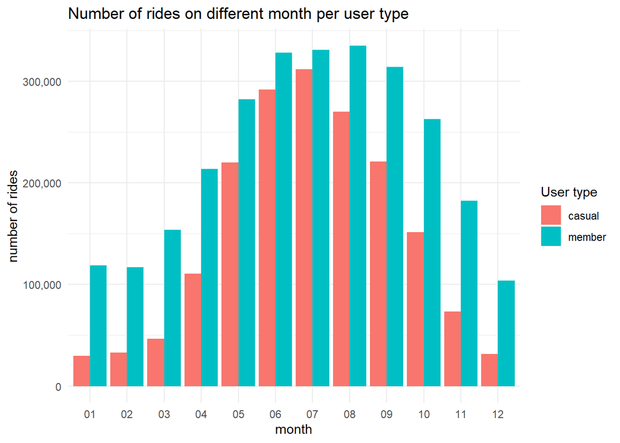

```r
Tripdatav2 %>%
ggplot(aes(x = month, fill = member_casual)) + geom_bar(position = "dodge") + scale_y_continuous(labels = scales::comma) + labs(title = "Number of rides on different month per user type", x="month", y="number of rides", fill = "User type") + theme_minimal()
```

Based on number of rides categorized by bike types - casual riders tend to use electric bikes more often on cold seasons where members always choose to ride classic bikes over electric ones.

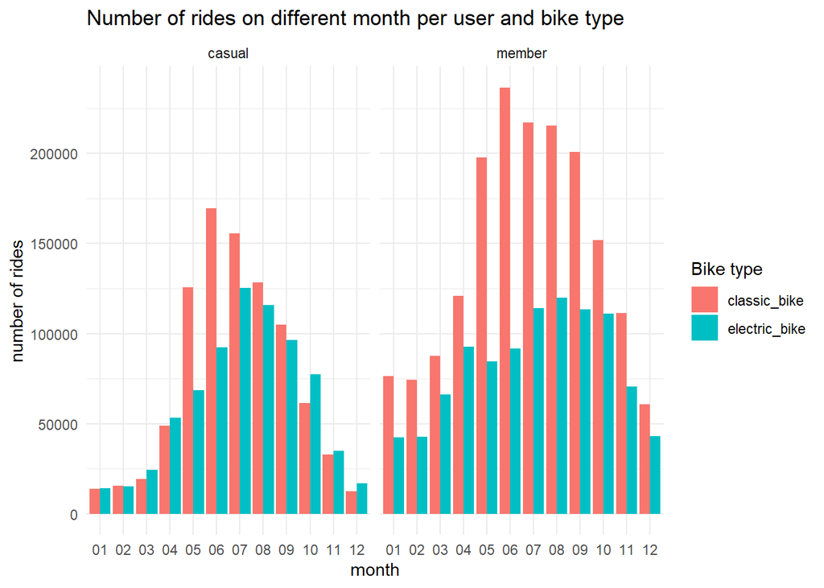

```r
Tripdatav2 %>%
  filter(rideable_type != "docked_bike") %>%
ggplot(aes(x = month, fill = rideable_type)) + geom_bar(position = "dodge") + facet_wrap(~member_casual) + labs(title = "Number of rides on different month per user and bike type", x="month", y="number of rides", fill = "Bike type") + theme_minimal()
```

This chart shows how day of the week affects average trip time per user type. For casual riders there’s a trend of increasing trip time from Wednesday to Sunday and decreasing trip time from Sunday to Wednesday, members have longest trips on Saturday

```
## Defaulting to continuous.
```

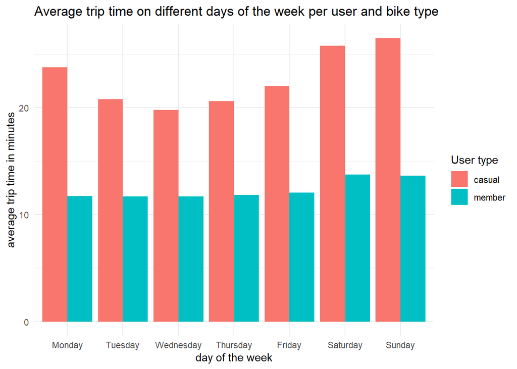

```r
Tripdatav2 %>%
ggplot(aes(x = dayoftheweek, y= trip_time/60, fill=member_casual)) + geom_bar(stat = "summary", fun = "mean", position = "dodge") + labs(title = "Average trip time on different days of the week per user and bike type", x="day of the week", y="average trip time in minutes", fill = "User type") + theme_minimal()
```

Last chart showing how day of the week affects number of rides per user type. Members perform more rides in working days and casual riders start to use bikes more on weekend.

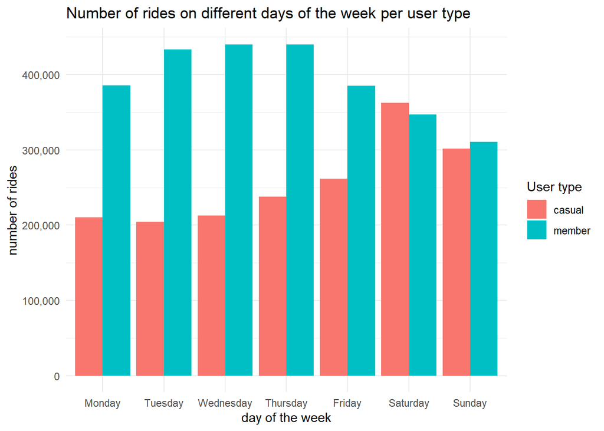

```r
Tripdatav2 %>%
ggplot(aes(x = dayoftheweek, fill = member_casual)) + geom_bar(position = "dodge") + scale_y_continuous(labels = scales::comma) +  labs(title = "Number of rides on different days of the week per user type", x="day of the week", y="number of rides", fill = "User type") + theme_minimal()
```

## Act - top 3 recomendations based on analysis

**Summarizing:**

-Casual riders perform longer trips.

-Casual riders tend to use bikes more often on warm seasons, performing longer trips.

-Casual riders use more electric bikes in colder seasons.

-Casual riders use perform more rides on weekend when members perform more rides on working days.

**What’s next?**

-It’s good to see how weather affects bike usage

-Adding another subscription with cheaper electric bike renting prices would beneficent for casual riders

-Increasing renting prices for causal riders on weekend would put the subscription option in a favorable light

-Adding loyalty program which would give customers possibilities to earn free electric bike rides after certain amount of time would be motivating to buy a subscription